# Computing sequence likelihoods

Sun Nov 15 21:47:09 2015

The basic result is that if $L_k$ is the log-likelihood of all the $(k,w)$ T-mers in a sequence, and $w$ and $k$ are long enough, then $L_{k+1}-L_k$ should equal the likelihood of the entire sequence.

Let’s check this.

# Computing the likelihood

Here’s a function to compute the likelihood. Note that the full likelihood of the *counts* includes a combinatorial factor for where the T-mers occur, but we *don’t want* that factor.

```r
# opt will be a list with 'longwin', 'shortwin', and 'leftwin' defined.

likelihood_fun <- function (opt,config,seq) {
    ## count-seq: count T-mers
    longpats <- getpatterns(opt$longwin,config$bases)
    shortpats <- getpatterns(opt$shortwin,config$bases)
    counts <- counttrans.list( list(longpats,shortpats),
        seqlist=seq[c("initseq","finalseq")],
        leftwin=opt$leftwin, bases=config$bases,
        shift=0, cyclic=TRUE )

    ## make-genmatrix
    genmatrix <- do.call( makegenmatrix, c( list( patlen=opt$longwin ), boundary="none", config ) )
    projmatrix <- collapsepatmatrix( ipatterns=rownames(genmatrix), leftwin=leftwin(counts), fpatterns=colnames(counts) )
    # this is collapsed transition matrix
    subtransmatrix <- computetransmatrix( genmatrix, projmatrix, tlen=seq$tlen, time="fixed")
    # return log-likelihood (*not* negative log-likelihood)
    ans <- sum( counts@counts * log(subtransmatrix) )
    dummy <- function() { 1 } # this will allow us access back to this environment

    return(list(loglik=ans,dummy=dummy))
}
```

# The simplest model

Let’s start with a model without context-dependence.

```r
acgt.config.json <- '{
    "bases" : [ "A", "C", "G", "T" ],
    "initfreqs" : [ 0.25, 0.25, 0.25, 0.25 ],
    "mutpats" : [
        [ [ "A", "T" ] ],
        [ [ "T", "A" ] ],
        [ [ "C", "G" ] ],
        [ [ "G", "C" ] ],
        [ [ "A", "C" ] ],
        [ [ "T", "G" ] ],
        [ [ "A", "G" ] ],
        [ [ "T", "C" ] ],
        [ [ "C", "A" ] ],
        [ [ "G", "T" ] ],
        [ [ "C", "T" ] ],
        [ [ "G", "A" ] ]
    ],
    "mutrates" : [ 1.0, 1.0, 1.0, 1.0, 1.0, 1.0, 1.0, 1.0, 1.0, 1.0, 1.0, 1.0 ]
}'
acgt.config <- fill.default.config(read.config(json=acgt.config.json))
```

```
## Config:  {"bases":["A","C","G","T"],"initfreqs":[0.25,0.25,0.25,0.25],"mutpats":[[["A","T"]],[["T","A"]],[["C","G"]],[["G","C"]],[["A","C"]],[["T","G"]],[["A","G"]],[["T","C"]],[["C","A"]],[["G","T"]],[["C","T"]],[["G","A"]]],"mutrates":[1,1,1,1,1,1,1,1,1,1,1,1]}
```

## Long time

First, we’ll do it for a long time, so the distribution should be uniform:

```r
seq <- simseq.config( seqlen=100, tlen=10.0, config=acgt.config )
```

```
## simseq: Total number of potential substitutions around  3000
```

```r
opts.numerator <- list(
            list(longwin=4, shortwin=2, leftwin=1),
            list(longwin=5, shortwin=3, leftwin=1),
            list(longwin=6, shortwin=4, leftwin=1)
        )
opts.denominator <- lapply( opts.numerator, function (x) { x$shortwin <- x$shortwin-1; x } )
loglik.numerators <- loglik.denominators <- list()
for (k in seq_along(opts.numerator)) {
    loglik.numerators[[k]] <- likelihood_fun( opts.numerator[[k]], config=acgt.config, seq=seq )
    loglik.denominators[[k]] <- likelihood_fun( opts.denominator[[k]], config=acgt.config, seq=seq )
}
results <- data.frame(
      longwin=sapply(opts.numerator,"[[","longwin"),
      numerators=sapply(loglik.numerators,"[[","loglik"),
      denominators=sapply(loglik.denominators,"[[","loglik"),
      theory=(-1)*length(seq[["initseq"]])*log(4)
      )
results$est_loglik <- results$numerators-results$denominators
results
```

```
##   longwin numerators denominators    theory est_loglik
## 1       4  -277.2589    -138.6294 -138.6294  -138.6294
## 2       5  -415.8883    -277.2589 -138.6294  -138.6294
## 3       6  -554.5177    -415.8883 -138.6294  -138.6294
```

The likelihood differences should be close to the theory. Note that we’re treating the string as cyclic, so we don’t need to worry about edge effects.

## Less long time

```r
seq <- simseq.config( seqlen=100, tlen=0.1, config=acgt.config )
```

```
## simseq: Total number of potential substitutions around  30
```

```r
theoretical <- function (seq) {
    n <- length(seq$initseq)
    m <- stringDist( DNAStringSet( seq[c("initseq","finalseq")]), method="hamming" )
    m * ( log((1-exp(-4*seq$tlen))/4) ) + (n-m) * log( exp(-4*seq$tlen) - expm1(-4*seq$tlen)/4)
}
opts.numerator <- list(
            list(longwin=4, shortwin=2, leftwin=1),
            list(longwin=5, shortwin=3, leftwin=1),
            list(longwin=6, shortwin=4, leftwin=1)
        )
opts.denominator <- lapply( opts.numerator, function (x) { x$shortwin <- x$shortwin-1; x } )
loglik.numerators <- loglik.denominators <- list()
for (k in seq_along(opts.numerator)) {
    loglik.numerators[[k]] <- likelihood_fun( opts.numerator[[k]], config=acgt.config, seq=seq )
    loglik.denominators[[k]] <- likelihood_fun( opts.denominator[[k]], config=acgt.config, seq=seq )
}
results <- data.frame(
      longwin=sapply(opts.numerator,"[[","longwin"),
      numerators=sapply(loglik.numerators,"[[","loglik"),
      denominators=sapply(loglik.denominators,"[[","loglik"),
      theory=as.numeric(theoretical(seq))
      )
results$est_loglik <- results$numerators-results$denominators
results
```

```
##   longwin numerators denominators    theory est_loglik
## 1       4  -154.1303    -77.06516 -77.06516  -77.06516
## 2       5  -231.1955   -154.13032 -77.06516  -77.06516
## 3       6  -308.2606   -231.19547 -77.06516  -77.06516
```

The “diff” column should match the “theory” column.

# Simple, context-dependent model

Now, let’s check this looks sensible for a simple context-dependent one.

```r
xo.config.json <- '{
    "bases" : [ "O", "X" ],
    "initfreqs" : [ 0.5, 0.5 ],
    "mutpats" : [
        [ [ "O", "X" ], [ "X", "O" ] ],
        [ [ "OO", "XX" ], [ "XX", "OO" ] ]
    ],
    "mutrates" : [ 1.0, 1.0 ]
}'
xo.config <- fill.default.config(read.config(json=xo.config.json))
```

```
## Config:  {"bases":["O","X"],"initfreqs":[0.5,0.5],"mutpats":[[["O","X"],["X","O"]],[["OO","XX"],["XX","OO"]]],"mutrates":[1,1]}
```

```r
xo.seq <- simseq.config( seqlen=10000, tlen=0.1, config=xo.config )
```

```
## simseq: Total number of potential substitutions around  2000
```

```r
opts.numerator <- list(
            list(longwin=4, shortwin=2, leftwin=1),
            list(longwin=6, shortwin=2, leftwin=2),
            list(longwin=8, shortwin=2, leftwin=3),
            list(longwin=5, shortwin=3, leftwin=1),
            list(longwin=7, shortwin=3, leftwin=2),
            list(longwin=8, shortwin=3, leftwin=3),
            list(longwin=9, shortwin=3, leftwin=3),
            list(longwin=6, shortwin=4, leftwin=1),
            list(longwin=8, shortwin=4, leftwin=2)
        )
opts.denominator <- lapply( opts.numerator, function (x) { x$shortwin <- x$shortwin-1; x } )
loglik.numerators <- loglik.denominators <- list()
for (k in seq_along(opts.numerator)) {
    loglik.numerators[[k]] <- likelihood_fun( opts.numerator[[k]], config=xo.config, seq=xo.seq )
    loglik.denominators[[k]] <- likelihood_fun( opts.denominator[[k]], config=xo.config, seq=xo.seq )
}
results <- data.frame(
      longwin=sapply(opts.numerator,"[[","longwin"),
      shortwin=sapply(opts.numerator,"[[","shortwin"),
      numerators=sapply(loglik.numerators,"[[","loglik"),
      denominators=sapply(loglik.denominators,"[[","loglik")
      )
results$est_loglik <- results$numerators-results$denominators
results
```

```
##   longwin shortwin numerators denominators est_loglik
## 1       4        2  -8669.598    -4432.301  -4237.298
## 2       6        2  -8670.345    -4431.544  -4238.801
## 3       8        2  -8670.327    -4431.546  -4238.782
## 4       5        3 -12880.848    -8670.847  -4210.000
## 5       7        3 -12881.563    -8670.324  -4211.238
## 6       8        3 -12881.565    -8670.327  -4211.238
## 7       9        3 -12881.546    -8670.327  -4211.219
## 8       6        4 -17086.422   -12882.087  -4204.335
## 9       8        4 -17087.164   -12881.543  -4205.622
```

# With a prior on the branch length

Now, let’s modify the function to allow for a Gamma prior on the branch length, with shape $\alpha$ and scale $\theta$.

```r
# opt will be a list with 'longwin', 'shortwin', and 'leftwin' defined.
likelihood_fun_gamma <- function (opt,config,seq,shape,scale) {
    ## count-seq: count T-mers
    longpats <- getpatterns(opt$longwin,config$bases)
    shortpats <- getpatterns(opt$shortwin,config$bases)
    counts <- counttrans.list( list(longpats,shortpats),
        seqlist=seq[c("initseq","finalseq")],
        leftwin=opt$leftwin, bases=config$bases,
        shift=0, cyclic=TRUE )
    ## make-genmatrix
    genmatrix <- do.call( makegenmatrix, c( list( patlen=opt$longwin ), boundary="none", config ) )
    projmatrix <- collapsepatmatrix( ipatterns=rownames(genmatrix), leftwin=leftwin(counts), fpatterns=colnames(counts) )
    # this is collapsed transition matrix
    subtransmatrix <- computetransmatrix( genmatrix, projmatrix, tlen=scale, shape=shape, time="gamma")
    # return log-likelihood (*not* negative log-likelihood)
    ans <- sum( counts@counts * log(subtransmatrix) )
    dummy <- function() { 1 } # this will allow us access back to this environment
    return(list(loglik=ans,dummy=dummy))
}
```

## The first model

In the first model, in the expression for the likelihood we just need to adjust the probability of having mutated or not; the probability that a Gamma($k$,$\theta$) occurs before a Exponential(4) is
$$\begin{aligned}
\int_0^\infty \frac{1}{\Gamma(k)\theta^k} t^{k-1} e^{-t/\theta} e^{-4t} dt
&=
\int_0^\infty \frac{1}{\Gamma(k)\theta^k} t^{k-1} e^{-t\frac{4\theta+1}{\theta}} dt \\
&=
\frac{1}{\Gamma(k)\theta^k} \left(\frac{\theta}{4\theta+1}\right)^k \int_0^\infty u^{k-1} e^{-u} du \\
&=
\frac{1}{(4\theta+1)^k}
\end{aligned}$$
(also the Laplace transform for a Gamma distribution) and so the likelihood of a sequence with $m$ sites differing is, as above,
$$\begin{aligned}
\left( \frac{1}{(4θ+1)ᵏ} + \left(1-\frac{1}{(4\theta+1)ᵏ}\right) \frac{1}{4} \right)^{n-m}
\left( \left(1-\frac{1}{(4\theta+1)ᵏ}\right) \frac{1}{4} \right)^m .
\end{aligned}$$

```r
shape <- 3
scale <- 0.1/3

seq <- simseq.config( seqlen=100, tlen=0.1, config=acgt.config )
```

```
## simseq: Total number of potential substitutions around  30
```

```r
theoretical_gamma <- function (seq,shape,scale) {
    n <- length(seq$initseq)
    m <- stringDist( DNAStringSet( seq[c("initseq","finalseq")]), method="hamming" )
    p <- 1/(4*scale+1)^shape
    m * ( log((1-p)/4) ) + (n-m) * log( p + (1-p)/4 )
}
opts.numerator <- list(
            list(longwin=4, shortwin=2, leftwin=1),
            list(longwin=5, shortwin=3, leftwin=1),
            list(longwin=6, shortwin=4, leftwin=1)
        )
opts.denominator <- lapply( opts.numerator, function (x) { x$shortwin <- x$shortwin-1; x } )
loglik.numerators <- loglik.denominators <- list()
for (k in seq_along(opts.numerator)) {
    loglik.numerators[[k]] <- likelihood_fun_gamma( opts.numerator[[k]], config=acgt.config, seq=seq, shape=shape, scale=scale )
    loglik.denominators[[k]] <- likelihood_fun_gamma( opts.denominator[[k]], config=acgt.config, seq=seq, shape=shape, scale=scale )
}
results <- data.frame(
      longwin=sapply(opts.numerator,"[[","longwin"),
      shortwin=sapply(opts.numerator,"[[","shortwin"),
      numerators=sapply(loglik.numerators,"[[","loglik"),
      denominators=sapply(loglik.denominators,"[[","loglik"),
      theory=as.numeric(theoretical_gamma(seq, shape=shape, scale=scale))
      )
results$est_loglik <- results$numerators-results$denominators
results
```

```
##   longwin shortwin numerators denominators    theory est_loglik
## 1       4        2  -159.0206    -79.20212 -79.20212  -79.81847
## 2       5        3  -239.6771   -159.02059 -79.20212  -80.65652
## 3       6        4  -321.0683   -239.67711 -79.20212  -81.39124
```

The “diff” column should match the “theory” column.

# Finding the MLE for the time

We’ll do this with a lightly context-dependent model.

```r
cpg.config.json <- '{
    "bases" : [ "A", "C", "G", "T" ],
    "initfreqs" : [ 0.25, 0.25, 0.25, 0.25 ],
    "mutpats" : [
        [ [ "A", "T" ] ],
        [ [ "T", "A" ] ],
        [ [ "C", "G" ] ],
        [ [ "G", "C" ] ],
        [ [ "A", "C" ] ],
        [ [ "T", "G" ] ],
        [ [ "A", "G" ] ],
        [ [ "T", "C" ] ],
        [ [ "C", "A" ] ],
        [ [ "G", "T" ] ],
        [ [ "C", "T" ] ],
        [ [ "G", "A" ] ],
        [ [ "CG", "CT" ], [ "CG", "AG" ] ]
    ],
    "mutrates" : [ 1.0, 1.0, 1.0, 1.0, 1.0, 1.0, 1.0, 1.0, 1.0, 1.0, 1.0, 1.0, 0.8 ]
}'
cpg.config <- fill.default.config(read.config(json=cpg.config.json))
```

```
## Config:  {"bases":["A","C","G","T"],"initfreqs":[0.25,0.25,0.25,0.25],"mutpats":[[["A","T"]],[["T","A"]],[["C","G"]],[["G","C"]],[["A","C"]],[["T","G"]],[["A","G"]],[["T","C"]],[["C","A"]],[["G","T"]],[["C","T"]],[["G","A"]],[["CG","CT"],["CG","AG"]]],"mutrates":[1,1,1,1,1,1,1,1,1,1,1,1,0.8]}
```

## Fixed times

Let $P_t = e^{tG}$. This involves computing $P_t V$, where $V$ is a projection matrix. If we’ve already computed this for $t$, and want to check the likelihood for $t+s$, then we need $P_{t+s} V = P_s P_t V$ – so, the previous sub-transition matrix $P_t V$ can be re-used for larger times.

```r
t_lhoods <- function (opt, config, seq, dt, ndt) {
    ans <- numeric(ndt)
    longpats <- getpatterns(opt$longwin,config$bases)
    shortpats <- getpatterns(opt$shortwin,config$bases)
    counts <- counttrans.list( list(longpats,shortpats),
        seqlist=seq[c("initseq","finalseq")],
        leftwin=opt$leftwin, bases=config$bases,
        shift=0, cyclic=TRUE )
    genmatrix <- do.call( makegenmatrix, c( list( patlen=opt$longwin ), boundary="none", config ) )
    projmatrix <- collapsepatmatrix( ipatterns=rownames(genmatrix), leftwin=leftwin(counts), fpatterns=colnames(counts) )
    subtransmatrix <- projmatrix
    for (k in 1:ndt) {
        subtransmatrix <- computetransmatrix( genmatrix, subtransmatrix, tlen=dt, time="fixed")  # add time dt
        # return log-likelihood (*not* negative log-likelihood)
        ans[k] <- sum( counts@counts * log(subtransmatrix) )
    }
    return(ans)
}
lower_opt <- function (x) { x$shortwin <- (x$shortwin-1); x }
```

OK, here’s the likelihood profile:

```r
cpg.seq <- simseq.config( seqlen=10000, tlen=0.1, config=cpg.config )
```

```
## simseq: Total number of potential substitutions around  4600
```

```r
opts <- list(
            list(longwin=4, shortwin=2, leftwin=1),
            list(longwin=4, shortwin=1, leftwin=1)
        )
dt <- .005
ndt <- ceiling(.2/dt)
tt <- (1:ndt)*dt
numerators <- t_lhoods(opts[[1]], cpg.config, cpg.seq, dt, ndt )
denominators <- t_lhoods(lower_opt(opts[[1]]), cpg.config, cpg.seq, dt, ndt )
cbind(tlen=seq$tlen,num=numerators,den=denominators,diff=numerators-denominators)
```

```
##       tlen       num        den       diff
##  [1,]  0.1 -27192.29 -13600.047 -13592.241
##  [2,]  0.1 -23929.52 -11968.687 -11960.835
##  [3,]  0.1 -22136.00 -11071.947 -11064.051
##  [4,]  0.1 -20943.18 -10475.559 -10467.620
##  [5,]  0.1 -20078.87 -10043.423 -10035.443
##  [6,]  0.1 -19421.81  -9714.912  -9706.896
##  [7,]  0.1 -18907.32  -9457.684  -9449.635
##  [8,]  0.1 -18496.78  -9252.431  -9244.352
##  [9,]  0.1 -18165.29  -9086.697  -9078.593
## [10,]  0.1 -17895.83  -8951.974  -8943.851
## [11,]  0.1 -17676.25  -8842.194  -8834.056
## [12,]  0.1 -17497.60  -8752.874  -8744.726
## [13,]  0.1 -17353.06  -8680.608  -8672.456
## [14,]  0.1 -17237.35  -8622.748  -8614.597
```

[output cut: 26 more lines]

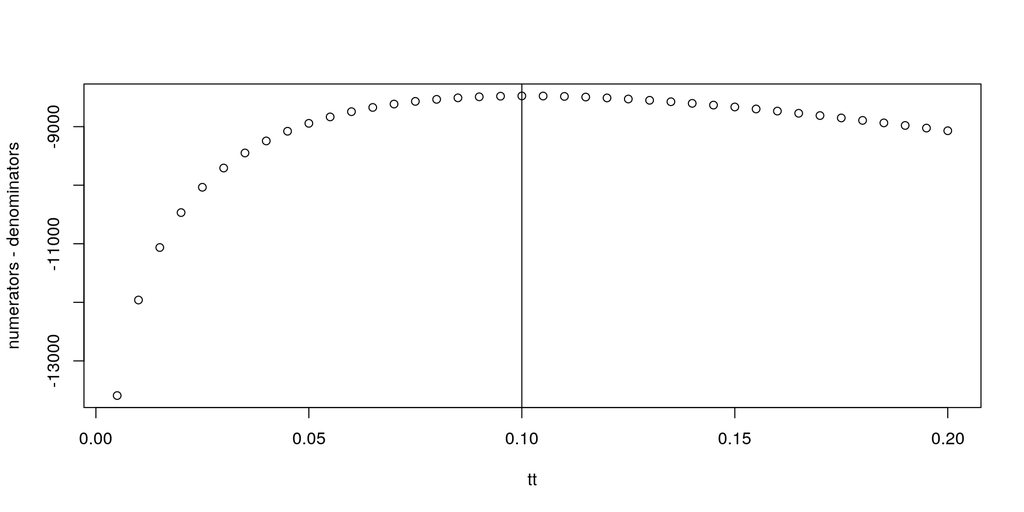

```r
plot( tt, numerators-denominators )
abline(v=seq$tlen)
```

## Exponential times

Consider the case $k=1$, i.e., Exponential. Let $\lambda = \max_i -G_{ii}$ and $Q_{ij} = G_{ij}/\lambda$ and $Q_{ii}=-\sum_{j \neq i} G_{ij}$, so that the process jumps as $Q$ at the times of a Poisson($\lambda$) process. As described in context/writeups/gamma-prob.html, to move from an Exponential($1/\theta$) time to an Exponential($1/(\theta+u)$) time, we need to add either zero jumps (with probability $\theta/(\theta+u)$) or a Geometric($\lambda(\theta+u)/(1+\lambda(\theta+u))$) number of jumps. This is done by `extend.expAtv`; a similar thing could be done for Gamma times with shape not equal to 1.

```r
e_lhoods <- function (opt, config, seq, dscale, ndscale) {
    ans <- numeric(ndscale)
    longpats <- getpatterns(opt$longwin,config$bases)
    shortpats <- getpatterns(opt$shortwin,config$bases)
    counts <- counttrans.list( list(longpats,shortpats),
        seqlist=seq[c("initseq","finalseq")],
        leftwin=opt$leftwin, bases=config$bases,
        shift=0, cyclic=TRUE )
    genmatrix <- do.call( makegenmatrix, c( list( patlen=opt$longwin ), boundary="none", config ) )
    projmatrix <- collapsepatmatrix( ipatterns=rownames(genmatrix), leftwin=leftwin(counts), fpatterns=colnames(counts) )
    # subtransmatrix <- computetransmatrix( genmatrix, projmatrix, tlen=dscale, time="gamma")  # add scale dscale
    subtransmatrix <- projmatrix
    scale <- 0
    for (k in 1:ndscale) {
        subtransmatrix <- extend.expAtv( A=genmatrix, scale=scale, dscale=dscale, gAtv=subtransmatrix )  # add scale dscale
        # return log-likelihood (*not* negative log-likelihood)
        ans[k] <- sum( counts@counts * log(subtransmatrix) )
    }
    return(ans)
}
lower_opt <- function (x) { x$shortwin <- (x$shortwin-1); x }
```

OK, here’s the likelihood profile:

```r
scale <- 0.1
shape <- 1
nseqs <- 1000
seqlen <- 100
random.tlen <- rgamma(nseqs,scale=scale,shape=shape)
expl.seqs <- simseq.config( seqlen=seqlen, tlen=random.tlen, config=cpg.config )
```

```
## simseq: Total number of potential substitutions around  0.0724882001288268 to 366.614584915531
```

```r
expl.seq <- list(
        initseq = do.call( xscat, lapply(expl.seqs,"[[","initseq") ),
        finalseq = do.call( xscat, lapply(expl.seqs,"[[","finalseq") ),
        scale=scale,
        shape=shape
    )
opts <- list(
            list(longwin=4, shortwin=2, leftwin=1)
        )
dscale <- .005
ndscale <- ceiling(.2/dt)
scalevals <- (1:ndscale)*dscale
numerators <- e_lhoods(opts[[1]], cpg.config, expl.seq, dscale, ndscale )
denominators <- e_lhoods(lower_opt(opts[[1]]), cpg.config, expl.seq, dscale, ndscale )
cbind(scale=scalevals,num=numerators,den=denominators,diff=numerators-denominators)
```

```
##       scale       num        den       diff
##  [1,] 0.005 -224942.3 -114638.76 -110303.50
##  [2,] 0.010 -199995.0 -101166.74  -98828.22
##  [3,] 0.015 -186196.6  -93865.33  -92331.31
##  [4,] 0.020 -177069.2  -89086.05  -87983.19
##  [5,] 0.025 -170533.2  -85685.45  -84847.73
##  [6,] 0.030 -165647.5  -83154.20  -82493.25
##  [7,] 0.035 -161904.4  -81220.55  -80683.82
##  [8,] 0.040 -158998.3  -79722.28  -79276.04
##  [9,] 0.045 -156730.8  -78554.73  -78176.10
## [10,] 0.050 -154965.6  -77646.42  -77319.22
## [11,] 0.055 -153605.1  -76946.35  -76658.75
## [12,] 0.060 -152576.8  -76416.85  -76159.99
## [13,] 0.065 -151825.7  -76029.30  -75796.39
## [14,] 0.070 -151308.6  -75761.44  -75547.20
```

[output cut: 26 more lines]

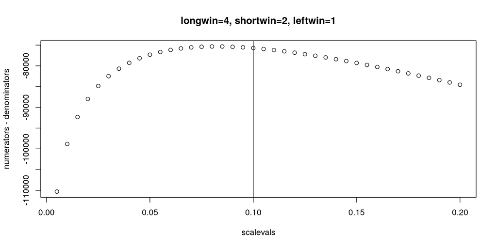

```r
plot( scalevals, numerators-denominators, main=paste( names(opts[[1]]), opts[[1]], sep="=", collapse=", ") )
abline(v=expl.seq$scale)
```

Hm, let’s try that again with a longer window?

```r
longer.opt <- list( longwin=6, shortwin=2, leftwin=2 )
numerators <- e_lhoods(longer.opt, cpg.config, expl.seq, dscale, ndscale )
denominators <- e_lhoods(lower_opt(longer.opt), cpg.config, expl.seq, dscale, ndscale )
cbind(scale=scalevals,num=numerators,den=denominators,diff=numerators-denominators)
```

```
##       scale       num        den       diff
##  [1,] 0.005 -224942.2 -114638.75 -110303.45
##  [2,] 0.010 -199994.9 -101166.73  -98828.19
##  [3,] 0.015 -186196.6  -93865.32  -92331.29
##  [4,] 0.020 -177069.2  -89086.04  -87983.18
##  [5,] 0.025 -170533.2  -85685.45  -84847.72
##  [6,] 0.030 -165647.4  -83154.20  -82493.24
##  [7,] 0.035 -161904.4  -81220.55  -80683.81
##  [8,] 0.040 -158998.3  -79722.27  -79276.03
##  [9,] 0.045 -156730.8  -78554.72  -78176.09
## [10,] 0.050 -154965.6  -77646.41  -77319.21
## [11,] 0.055 -153605.1  -76946.34  -76658.74
## [12,] 0.060 -152576.8  -76416.84  -76159.98
## [13,] 0.065 -151825.7  -76029.29  -75796.39
## [14,] 0.070 -151308.6  -75761.44  -75547.20
```

[output cut: 26 more lines]

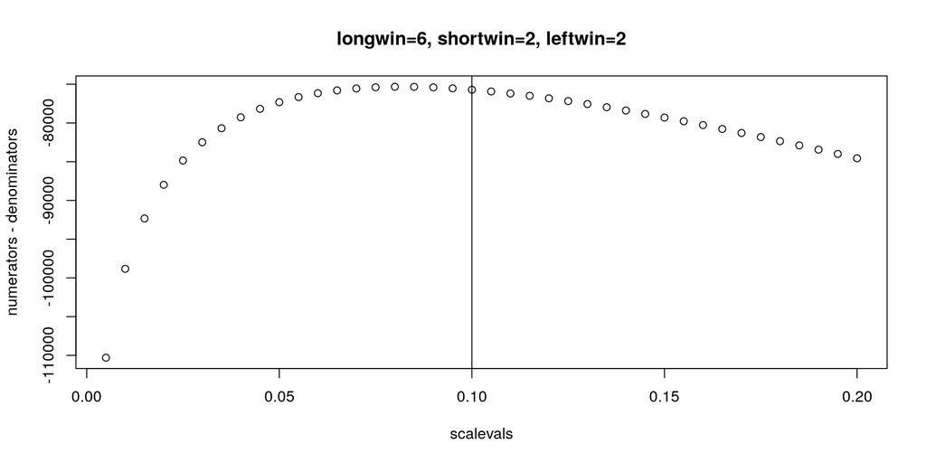

```r
plot( scalevals, numerators-denominators, main=paste( names(longer.opt), longer.opt, sep="=", collapse=", ") )
abline(v=expl.seq$scale)
```

# Not useful or not used

## Gamma inference

Let $f(t;k,\theta)$ be the density function for a Gamma distribution with shape $k$ and scale $\theta$ (and hence mean $k \theta$). Define
$$P_{k,\theta} = \int_0^\infty f(t;k,\theta) P_t dt ,$$
i.e., the transition matrix after a Gamma($k$,$\theta$)-distributed time. If $T_i$ are independent, Gamma($k_i$,$\theta$), then $\sum_i T_i$ is Gamma($\sum_i k_i$,$\theta$), and so
$$\begin{aligned}
P_{k_1,\theta} P_{k_2,\theta} &= P_{k_1+k_2,\theta} .
\end{aligned}$$

For $k$ an integer, since a Gamma($k$,$\theta$) is the sum of $k$ independent Exponential($1/\theta$) times, and by Poisson thinning, a Gamma($k$,$\theta/(1-\epsilon)$) is the sum of a NegativeBinomial($k$,$1-\epsilon$) number of Exponential($1/\theta$) times, i.e., the number of times to flip a $1-\epsilon$ coin until getting $k$ heads, so
$$\begin{aligned}
P_{k,\theta/(1-\epsilon)}
&=
\sum_{n \ge 0}
\binom{n+k-1}{n} \epsilon^{n} (1-\epsilon)^k
P_{1,\theta}^{n+k} .
\end{aligned}$$
Or, to get a Gamma($k$,$\theta/(1-\epsilon)$), we could start with a Gamma($k$,$\theta$), and add on $M$ indepenent Exponential($1/\theta$) times, where $M$ is NegativeBinomial($N$,$1-\epsilon$) and $N$ is Binomial($k$,$\epsilon$).

## Extending gamma times

Now consider the case $k=1$. By Poisson thinning, a Geometric($p$) number of independent Exponential($\lambda$) times is Exponential($\lambda p$); and therefore
$$\begin{aligned}
P_{1,\theta/(1-\epsilon)}
&=
\sum_{n \ge 1}
\epsilon^{n-1} (1-\epsilon)
P_{1,\theta}^n \\
&=
\sum_{n=1}^k
\epsilon^{n-1} (1-\epsilon)
P_{1,\theta}^n
+ O(\epsilon^k) .
\end{aligned}$$

```r
extend_transmatrix <- function (P,a,da,eps=da/(a+da),tol=1e-8) {
    # if P is e^{TG} where T is Exp(a)
    #   return e^{SG} where S is Exp(a+da), with da>0.
    # as above, a+da = a/(1-eps), so eps=(da/a)/(1+da/a)
    ans <- Pm <- (1-eps)*P
    m <- ceiling(log(tol)/log(eps))
    # cat("m=",m,"\n")
    for (k in seq(2,length.out=(m-1))) {
        Pm <- eps * P %*% Pm
        ans <- ans + Pm
    }
    return(ans)
}
# prob an exponential(theta) is greater than an exponential(1) is 1/(1+theta), so:
stopifnot( abs( 1/(1+0.25/.8) - extend_transmatrix( 1/(1+0.25), eps=0.2 ) ) <= 1e-8 )
stopifnot( abs( 1/(1+0.25/.8) - extend_transmatrix( 1/(1+0.25), eps=0.2, tol=1e-15 ) ) <= 1e-15 )
```

Here’s a quick check of this:

```r
## one step
scale <- 0.3
genmatrix <- do.call( makegenmatrix, c( list( patlen=2 ), boundary="none", acgt.config ) )
subtransmatrix <- computetransmatrix( genmatrix, Diagonal(nrow(genmatrix)), tlen=scale, shape=1, time="gamma", tol=1e-12 )
stm1 <- extend_transmatrix( subtransmatrix, eps=.2, tol=1e-12 )
stm2 <- computetransmatrix( genmatrix, Diagonal(nrow(genmatrix)), tlen=scale/0.8, shape=1, time="gamma", tol=1e-12 )
range(stm1-stm2)
```

```
## [1] -2.262079e-14  2.814415e-14
```

```r
stopifnot(all(abs(stm1-stm2)<1e-12))
## more steps
tt <- seq(0,scale,length.out=11)[-1]
stm.list <- vector(length(tt),mode='list')
stm.list[[1]] <- computetransmatrix( genmatrix, Diagonal(nrow(genmatrix)), tlen=tt[1], shape=1, time="gamma", tol=1e-12 )
for (k in seq_along(tt)[-1]) {
    stm.list[[k]] <- extend_transmatrix( stm.list[[k-1]], a=tt[k-1], da=diff(tt)[k-1], tol=1e-12 )
}
range(subtransmatrix-stm.list[[length(tt)]])
```

```
## [1] 1.559863e-13 7.963734e-13
```

```r
stopifnot(all(abs(subtransmatrix-stm.list[[length(tt)]])<1e-12))
```

Now let’s look at inference. Hm, since we’re actually dealing with $P_{k,\theta} v$ instead of $P_{k,\theta}$ itself, maybe that’s not too useful.